# QMSS5073 HW3

## If you want to make a good bottle of wine, then what characteristics are most important according to this analysis? Have your conclusions changed using Hierarchical clustering rather than k means clustering? Present any figures that assist you in your analysis.

```python
#Standard Scale the red wine dataframe
col_names = red_df.columns
std_scaler = StandardScaler()

red_scaled = std_scaler.fit_transform(red_df.to_numpy())
red_scaled = pd.DataFrame(red_scaled, columns = col_names)
```

```python
from sklearn.cluster import AgglomerativeClustering

ac = AgglomerativeClustering(n_clusters=7,   # note that we select the clusters
                             affinity='euclidean',
                             linkage='complete')
labels = ac.fit_predict(red_scaled)    # extract cluster labels for each observation in data
red_scaled['cluster'] = labels
red_scaled.groupby('cluster').mean().sort_values('quality')
```

| cluster | fixed acidity | volatile acidity | citric acid | residual sugar | chlorides | free sulfur dioxide | total sulfur dioxide | density | pH | sulphates | alcohol | quality |
| --- | --- | --- | --- | --- | --- | --- | --- | --- | --- | --- | --- | --- |
| 3 | 0.074897 | -0.350945 | 3.127368 | 0.043416 | 11.116408 | 0.394484 | 0.320274 | 0.770280 | -2.663717 | 5.735193 | -0.960246 | -1.407158 |
| 1 | 0.012429 | -0.100884 | 0.528057 | -0.328215 | 2.707187 | -0.106439 | 0.430325 | 0.260289 | -1.022300 | 2.585018 | -0.724833 | -0.335609 |
| 2 | 0.009946 | -0.002846 | -0.029360 | -0.042682 | -0.107648 | 0.023370 | -0.003717 | 0.069548 | 0.012269 | -0.125419 | -0.114821 | -0.027203 |
| 6 | 0.284822 | -0.598039 | 0.630946 | 6.832574 | 0.639140 | 0.982981 | 0.505067 | 1.903286 | -0.500635 | 0.115332 | -0.599218 | 0.069719 |
| 0 | -1.097587 | 0.430947 | -0.721546 | -0.283762 | -0.402129 | -0.181139 | -0.185685 | -1.592195 | 1.127159 | -0.297306 | 1.529161 | 0.165001 |
| 5 | 2.482856 | -0.657106 | 1.592896 | 0.192963 | -0.056174 | -0.471818 | -0.452472 | 1.468131 | -1.625762 | 0.646183 | 0.131191 | 0.669437 |
| 4 | -0.624115 | -1.291336 | 1.364336 | 5.293553 | -0.675866 | 3.167777 | 5.956069 | -1.185471 | -1.259873 | -0.815259 | 1.136122 | 1.276629 |

```python
red_scaled
```

|  | fixed acidity | volatile acidity | citric acid | residual sugar | chlorides | free sulfur dioxide | total sulfur dioxide | density | pH | sulphates | alcohol | quality | cluster |
| --- | --- | --- | --- | --- | --- | --- | --- | --- | --- | --- | --- | --- | --- |
| 0 | -0.528360 | 0.961877 | -1.391472 | -0.453218 | -0.243707 | -0.466193 | -0.379133 | 0.558274 | 1.288643 | -0.579207 | -0.960246 | -0.787823 | 2 |
| 1 | -0.298547 | 1.967442 | -1.391472 | 0.043416 | 0.223875 | 0.872638 | 0.624363 | 0.028261 | -0.719933 | 0.128950 | -0.584777 | -0.787823 | 2 |
| 2 | -0.298547 | 1.297065 | -1.186070 | -0.169427 | 0.096353 | -0.083669 | 0.229047 | 0.134264 | -0.331177 | -0.048089 | -0.584777 | -0.787823 | 2 |
| 3 | 1.654856 | -1.384443 | 1.484154 | -0.453218 | -0.264960 | 0.107592 | 0.411500 | 0.664277 | -0.979104 | -0.461180 | -0.584777 | 0.450848 | 2 |
| 4 | -0.528360 | 0.961877 | -1.391472 | -0.453218 | -0.243707 | -0.466193 | -0.379133 | 0.558274 | 1.288643 | -0.579207 | -0.960246 | -0.787823 | 2 |
| ... | ... | ... | ... | ... | ... | ... | ... | ... | ... | ... | ... | ... | ... |
| 1594 | -1.217796 | 0.403229 | -0.980669 | -0.382271 | 0.053845 | 1.542054 | -0.075043 | -0.978765 | 0.899886 | -0.461180 | 0.072294 | -0.787823 | 2 |
| 1595 | -1.390155 | 0.123905 | -0.877968 | -0.240375 | -0.541259 | 2.211469 | 0.137820 | -0.862162 | 1.353436 | 0.601055 | 0.729364 | 0.450848 | 2 |
| 1596 | -1.160343 | -0.099554 | -0.723916 | -0.169427 | -0.243707 | 1.255161 | -0.196679 | -0.533554 | 0.705508 | 0.542042 | 0.541630 | 0.450848 | 2 |
| 1597 | -1.390155 | 0.654620 | -0.775267 | -0.382271 | -0.264960 | 1.542054 | -0.075043 | -0.676657 | 1.677400 | 0.305990 | -0.209308 | -0.787823 | 2 |
| 1598 | -1.332702 | -1.216849 | 1.021999 | 0.752894 | -0.434990 | 0.203223 | -0.135861 | -0.666057 | 0.511130 | 0.010924 | 0.541630 | 0.450848 | 2 |

1599 rows × 13 columns

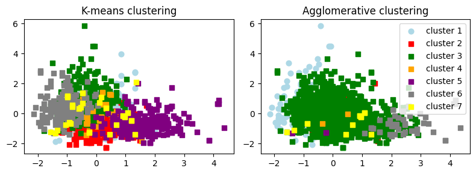

```python
f, (ax1, ax2) = plt.subplots(1, 2, figsize=(8, 3))


ax1.scatter(red_scaled.values[y_km == 0, 0], red_scaled.values[y_km == 0, 1], c='lightblue',
            marker='o', s=40, label='cluster 1')
ax1.scatter(red_scaled.values[y_km == 1, 0], red_scaled.values[y_km == 1, 1], c='red',
            marker='s', s=40, label='cluster 2')
ax1.scatter(red_scaled.values[y_km == 2, 0], red_scaled.values[y_km == 2, 1], c='green',
            marker='s', s=40, label='cluster 3')
ax1.scatter(red_scaled.values[y_km == 3, 0], red_scaled.values[y_km == 3, 1], c='orange',
            marker='s', s=40, label='cluster 4')
ax1.scatter(red_scaled.values[y_km == 4, 0], red_scaled.values[y_km == 4, 1], c='purple',
            marker='s', s=40, label='cluster 5')
ax1.scatter(red_scaled.values[y_km == 5, 0], red_scaled.values[y_km == 5, 1], c='gray',
            marker='s', s=40, label='cluster 6')
ax1.scatter(red_scaled.values[y_km == 6, 0], red_scaled.values[y_km == 6, 1], c='yellow',
            marker='s', s=40, label='cluster 7')
ax1.set_title('K-means clustering')

ax2.scatter(red_scaled.values[labels == 0, 0], red_scaled.values[labels == 0, 1], c='lightblue',
            marker='o', s=40, label='cluster 1')
ax2.scatter(red_scaled.values[labels == 1, 0], red_scaled.values[labels == 1, 1], c='red',
            marker='s', s=40, label='cluster 2')
ax2.scatter(red_scaled.values[labels == 2, 0], red_scaled.values[labels == 2, 1], c='green',
            marker='s', s=40, label='cluster 3')
ax2.scatter(red_scaled.values[labels == 3, 0], red_scaled.values[labels == 3, 1], c='orange',
            marker='s', s=40, label='cluster 4')
ax2.scatter(red_scaled.values[labels == 4, 0], red_scaled.values[labels == 4, 1], c='purple',
            marker='s', s=40, label='cluster 5')
ax2.scatter(red_scaled.values[labels == 5, 0], red_scaled.values[labels == 5, 1], c='gray',
            marker='s', s=40, label='cluster 6')
ax2.scatter(red_scaled.values[labels == 6, 0], red_scaled.values[labels == 6, 1], c='yellow',
            marker='s', s=40, label='cluster 7')

ax2.set_title('Agglomerative clustering')

plt.legend()
plt.tight_layout()
plt.show()
```

## 3. Use Principal Components Analysis to reduce the dimensions of your data. How much of the variation in your data is explained by the first two principal components. How might you use the first two components to do supervised learning on some other variable tied to wine (e.g. - wine price)?

```python
#Standard Scale the red wine dataframe
col_names = red_df.columns
std_scaler = StandardScaler()

red_scaled = std_scaler.fit_transform(red_df.to_numpy())
red_scaled = pd.DataFrame(red_scaled, columns = col_names)
```

```python
pca_2 = PCA(n_components=2).fit(red_scaled) # project from 12 to 2 dimensions
pca_2.explained_variance_ratio_.sum()
```

```
0.4469208117069173
```

### Around 44.69% of the variation in my data is explained by the first two principal components. We can set first two components as the independent variables and other variable like wine price as dependent variable. Since we are dealing with supervised linear regression problem, I can apply models like KNN, Linear Regression Model, Decision Tree Regressor, Random Forest Regressor, Bagging Model and SVM to predict our dependent variable.